# Tidy Stock Analysis Using R

Kansas City R Users Group

Douglas Kroencke

April 7, 2018

[figure not shown]

# Synopsis

Stock market analysis is fun and potentially profitable. This presentation will use the package **tidyquant** created by Matt Dancho<sup>[**1**](https://cran.r-project.org/package=tidyquant)</sup>. From the tidyquant documentation<sup>[**2**](https://cran.r-project.org/web/packages/tidyquant/vignettes/TQ00-introduction-to-tidyquant.html)</sup>, “All tidyquant functions return data in the tibble (tidy data frame) format, which allows for interaction within the tidyverse. … The tidyquant package includes charting tools to assist users in developing quick visualizations in ggplot2 using the grammar of graphics format and workflow.” Source code is available on GitHub<sup>[**3**](https://github.com/business-science/tidyquant)</sup>. The tidyquant website<sup>[**4**](https://business-science.github.io/tidyquant/)</sup> is another good source of information.

# Stock Analysis

### Initialize the R Environment

```r
# Get tidyquant - Loads tidyquant, tidyverse, lubridate, xts, quantmod, TTR, et al.
if (!require("tidyquant")) {

  install.packages("tidyquant")

  library(tidyquant)
}
```

### Stock Indexes

```r
tq_index_options()
```

```
## [1] "RUSSELL1000" "RUSSELL2000" "RUSSELL3000" "DOW"         "DOWGLOBAL"
## [6] "SP400"       "SP500"       "SP600"       "SP1000"
```

#### Example: DOW 30 Symbols

```r
tq_index("DOW")
```

| symbol | company | weight | sector | shares_held |
| --- | --- | --- | --- | --- |
| BA | Boeing Company | 0.096450685 | Industrials | 6252741 |
| GS | Goldman Sachs Group Inc. | 0.073663508 | Financials | 6252741 |
| MMM | 3M Company | 0.065366197 | Industrials | 6252741 |
| UNH | UnitedHealth Group Incorporated | 0.062155147 | Health Care | 6252741 |
| HD | Home Depot Inc. | 0.049214105 | Consumer Discretionary | 6252741 |
| AAPL | Apple Inc. | 0.048937541 | Information Technology | 6252741 |
| IBM | International Business Machines Corporation | 0.043204093 | Information Technology | 6252741 |
| MCD | McDonald's Corporation | 0.042714545 | Consumer Discretionary | 6252741 |
| CAT | Caterpillar Inc. | 0.042479457 | Industrials | 6252741 |
| TRV | Travelers Companies Inc. | 0.038629505 | Financials | 6252741 |

[output cut: 20 more lines]

### Stock Exchanges

```r
tq_exchange_options()
```

```
## [1] "AMEX"   "NASDAQ" "NYSE"
```

#### Example: NASDAQ Symbols

```r
tq_exchange("NASDAQ")
```

| symbol | company | last.sale.price | market.cap | ipo.year | sector | industry |
| --- | --- | --- | --- | --- | --- | --- |
| PIH | 1347 Property Insurance Holdings, Inc. | 6.8500 | $41M | 2014 | Finance | Property-Casualty Insurers |
| TURN | 180 Degree Capital Corp. | 1.9500 | $60.69M | NA | Finance | Finance/Investors Services |
| FLWS | 1-800 FLOWERS.COM, Inc. | 12.0500 | $777.67M | 1999 | Consumer Services | Other Specialty Stores |
| FCCY | 1st Constitution Bancorp (NJ) | 19.6000 | $158.42M | NA | Finance | Savings Institutions |
| SRCE | 1st Source Corporation | 53.1500 | $1.38B | NA | Finance | Major Banks |
| VNET | 21Vianet Group, Inc. | 8.2700 | $923.35M | 2011 | Technology | Computer Software: Programming, Data Processing |
| TWOU | 2U, Inc. | 87.8500 | $4.63B | 2014 | Technology | Computer Software: Prepackaged Software |
| JOBS | 51job, Inc. | 83.7100 | $5.17B | 2004 | Technology | Diversified Commercial Services |
| CAFD | 8point3 Energy Partners LP | 12.1400 | $960.14M | 2015 | Public Utilities | Electric Utilities: Central |
| EGHT | 8x8 Inc | 19.9000 | $1.83B | NA | Public Utilities | Telecommunications Equipment |

[output cut: 3279 more lines]

### Economic Data - FRED - St. Louis Fed

Download, graph, and track 508,000 US and international time series from 86 sources.<sup>[**5**](https://fred.stlouisfed.org/categories)</sup>

#### Example: West Texas Intermediate (WTI)

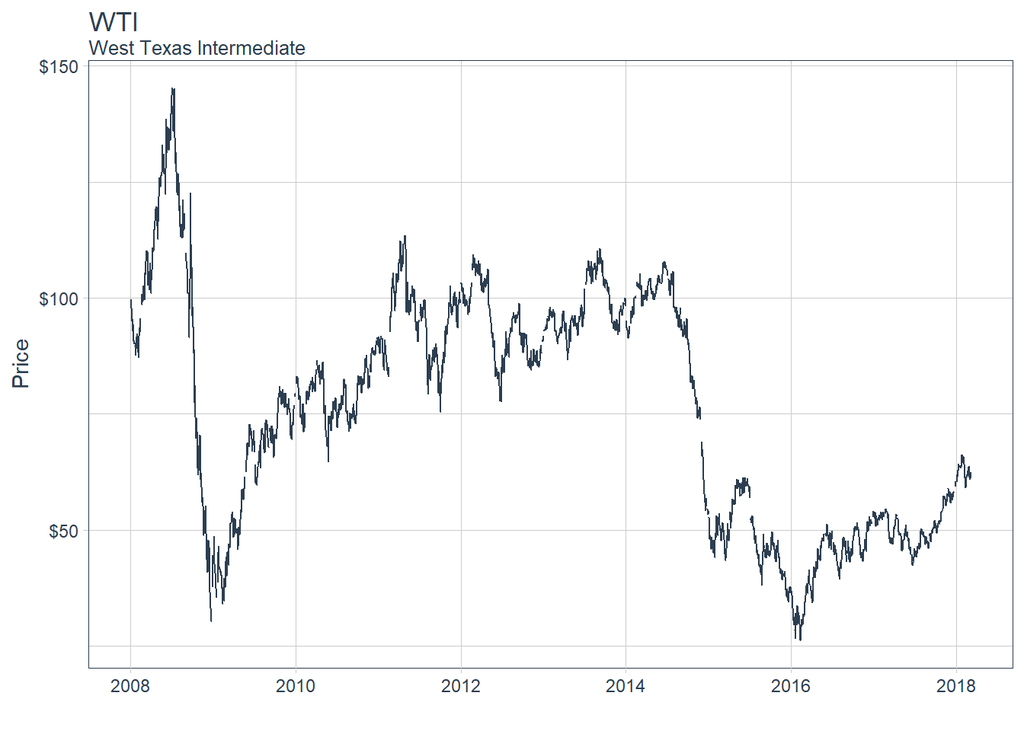

```r
wti_price_usd <- tq_get("DCOILWTICO", get = "economic.data")

wti_price_usd %>%
  ggplot(aes(x = date, y = price)) +
  geom_line(color = palette_light()[[1]]) +
  scale_y_continuous(labels = scales::dollar) +
  labs(title = "WTI",
       subtitle = "West Texas Intermediate",
       y = "Price", x = "") +
  theme_tq()
```

#### Example: Effective Federal Funds (FEDFUNDS)

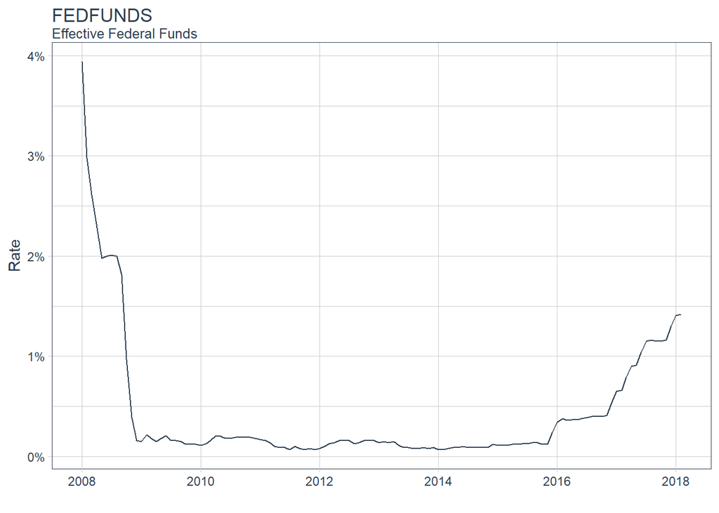

```r
fed_funds <- tq_get("FEDFUNDS", get = "economic.data")

fed_funds %>%
  ggplot(aes(x = date, y = price/100)) +
  geom_line(color = palette_light()[[1]]) +
  scale_y_continuous(labels = scales::percent) +
  labs(title = "FEDFUNDS",
       subtitle = "Effective Federal Funds",
       y = "Rate", x = "") +
  theme_tq()
```

#### Example: Smoothed U.S. Recession Probabilities (RECPROUSM156N)

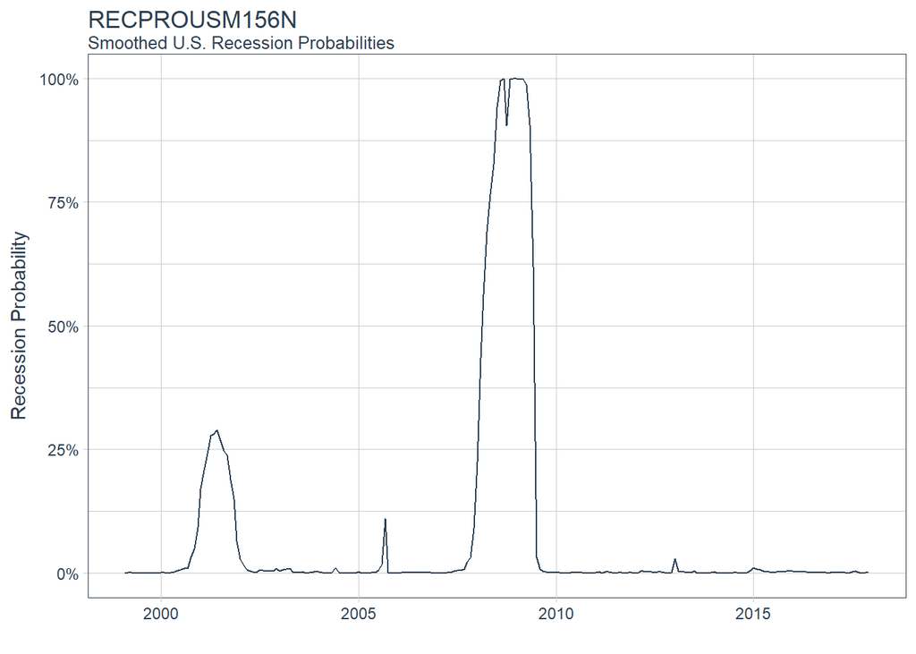

```r
recession_probabilities <- tq_get("RECPROUSM156N", get = "economic.data", from = "1967-06-01")

recession_probabilities %>%
  filter(date > as.Date("1999-01-01")) %>%
  ggplot(aes(x = date, y = price/100)) +
  geom_line(color = palette_light()[[1]]) +
  scale_y_continuous(labels = scales::percent) +
  labs(title = "RECPROUSM156N",
       subtitle = "Smoothed U.S. Recession Probabilities",
       y = "Recession Probability", x = "") +
  theme_tq()
```

### Quantitative Data

```r
tq_get_options()
```

```
##  [1] "stock.prices"        "stock.prices.google" "stock.prices.japan"
##  [4] "financials"          "key.ratios"          "dividends"
##  [7] "splits"              "economic.data"       "exchange.rates"
## [10] "metal.prices"        "quandl"              "quandl.datatable"
## [13] "alphavantager"       "rblpapi"
```

#### Example: AAPL - Financials - Annual

```r
aapl_financials <- tq_get("AAPL", get = "financials")

aapl_financials %>%
  filter(type == "IS") %>%
  select(annual) %>%
  unnest(annual) %>%
  spread(key = date, value = value)
```

|  | group | category | 2014-09-27 | 2015-09-26 | 2016-09-24 | 2017-09-30 |
| --- | --- | --- | --- | --- | --- | --- |
| 1 | 1 | Revenue | 182795.00 | 233715.00 | 215639.00 | 229234.00 |
| 2 | 2 | Other Revenue, Total | NA | NA | NA | NA |
| 3 | 3 | Total Revenue | 182795.00 | 233715.00 | 215639.00 | 229234.00 |
| 4 | 4 | Cost of Revenue, Total | 112258.00 | 140089.00 | 131376.00 | 141048.00 |
| 5 | 5 | Gross Profit | 70537.00 | 93626.00 | 84263.00 | 88186.00 |
| 6 | 6 | Selling/General/Admin. Expenses, Total | 11993.00 | 14329.00 | 14194.00 | 15261.00 |
| 7 | 7 | Research & Development | 6041.00 | 8067.00 | 10045.00 | 11581.00 |
| 8 | 8 | Depreciation/Amortization | NA | NA | NA | NA |
| 9 | 9 | Interest Expense(Income) - Net Operating | NA | NA | NA | NA |
| 10 | 10 | Unusual Expense (Income) | NA | NA | NA | NA |

[output cut: 39 more lines]

#### Example: AAPL - Key Ratios

```r
aapl_key_ratios <- tq_get("AAPL", get = "key.ratios")

aapl_key_ratios$section
```

```
## [1] "Financials"        "Profitability"     "Growth"
## [4] "Cash Flow"         "Financial Health"  "Efficiency Ratios"
## [7] "Valuation Ratios"
```

#### Example: AAPL - Valuation Ratios - Profitability

```r
aapl_key_ratios %>%
  filter(section == "Profitability") %>%
  unnest() %>%
  select(c(category,date,value)) %>%
  spread(key = date, value = value)
```

|  | category | 2008-09-01 | 2009-09-01 | 2010-09-01 | 2011-09-01 | 2012-09-01 | 2013-09-01 | 2014-09-01 | 2015-09-01 | 2016-09-01 | 2017-09-01 |
| --- | --- | --- | --- | --- | --- | --- | --- | --- | --- | --- | --- |
| 1 | Asset Turnover (Average) | 1.00 | 0.99 | 1.06 | 1.13 | 1.07 | 0.89 | 0.83 | 0.89 | 0.70 | 0.66 |
| 2 | COGS | 64.80 | 59.86 | 60.62 | 59.52 | 56.13 | 62.38 | 61.41 | 59.94 | 60.92 | 61.53 |
| 3 | EBT Margin | 23.86 | 28.12 | 28.42 | 31.60 | 35.63 | 29.35 | 29.26 | 31.03 | 28.46 | 27.96 |
| 4 | Financial Leverage (Average) | 1.88 | 1.50 | 1.57 | 1.52 | 1.49 | 1.68 | 2.08 | 2.43 | 2.51 | 2.80 |
| 5 | Gross Margin | 35.20 | 40.14 | 39.38 | 40.48 | 43.87 | 37.62 | 38.59 | 40.06 | 39.08 | 38.47 |
| 6 | Interest Coverage | NA | NA | NA | NA | NA | 369.79 | 140.28 | 99.93 | 43.15 | 28.59 |
| 7 | Net Int Inc & Other | 1.65 | 0.76 | 0.24 | 0.38 | 0.33 | 0.68 | 0.54 | 0.55 | 0.63 | 1.20 |
| 8 | Net Margin % | 14.88 | 19.19 | 21.48 | 23.95 | 26.67 | 21.67 | 21.61 | 22.85 | 21.19 | 21.09 |
| 9 | Operating Margin | 22.21 | 27.36 | 28.19 | 31.22 | 35.30 | 28.67 | 28.72 | 30.48 | 27.84 | 26.76 |
| 10 | Other | NA | NA | NA | NA | NA | NA | NA | NA | NA | NA |

[output cut: 7 more lines]

#### Example: AAPL - Valuation Ratios - Valuation Ratios

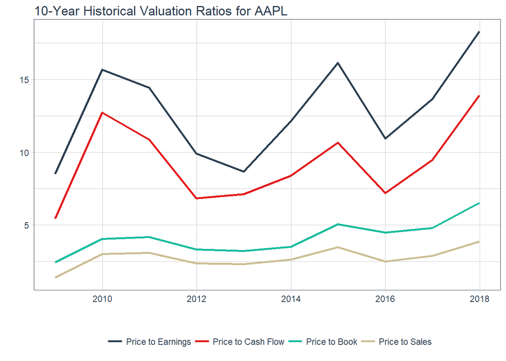

```r
aapl_key_ratios %>%
  filter(section == "Valuation Ratios") %>%
  unnest() %>%
  ggplot(aes(x = date, y = value)) +
  geom_line(aes(col = forcats::fct_reorder2(category, date, value)),
            size = 1) +
  labs(title = "10-Year Historical Valuation Ratios for AAPL", x = "",
       y = "", col = "") +
  theme_tq() +
  scale_color_tq()
```

### Download Historical Data for Dow 30 Stocks

Use tidyquant to pull down 20 years of daily historical data and save to CSV files.

```
## Downloaded daily historical data for Dow 30 stocks in 19.14 seconds.
```

[figure not shown]

Generated CSV Files

```r
data_dir <- "C:\\R-Projects\\StockData\\"

download.data <- function(symbol) {

  start <- as.Date("1998-01-01")

  end <- as.Date("2017-12-31")

  stock_data <- tq_get(symbol, get  = "stock.prices", from = start, to = end)

  file_name <- paste(data_dir, "Dow30_Daily_", symbol, ".csv",
                     sep = "", collapse = NULL)

  write.csv(stock_data, file = file_name)
}

symbols <- tq_index("DOW")$symbol

start_time <- proc.time()

for (i in 1:length(symbols)) {

  download.data(symbols[i])
}

elapsed_time <- (proc.time() - start_time)["elapsed"]

write.table(paste("Downloaded daily historical data for Dow 30 stocks in",
                  format(elapsed_time,digits=2,nsmall=2),"seconds."),
            row.names = FALSE, col.names = FALSE, quote = FALSE)
```

# Analysis Example: Apple (AAPL)

### Load Daily Historical Data

```r
start <- as_date("2016-01-01")

end <- as_date("2018-03-10")

AAPL <- tq_get("AAPL", get = "stock.prices", from = start, to = end)
```

### Closing Price with Linear Trendline

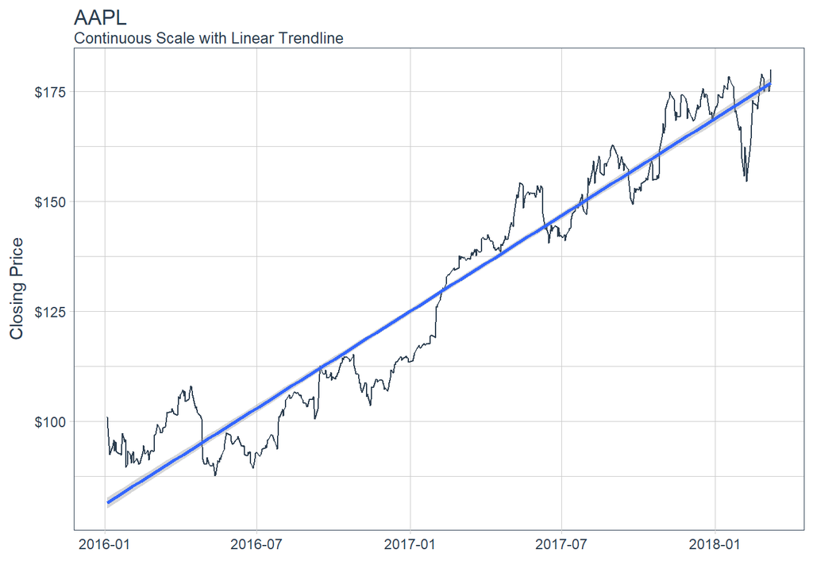

```r
AAPL %>%
  ggplot(aes(x = date, y = adjusted)) +
  geom_line(color = palette_light()[[1]]) +
  scale_y_continuous(labels = scales::dollar) +
  geom_smooth(method = "lm") +
  labs(title = "AAPL",
       subtitle = "Continuous Scale with Linear Trendline",
       y = "Closing Price", x = "") +
  theme_tq()
```

### Closing Price with Simple Moving Averages

[figure not shown]

```r
img   <- png::readPNG("tidyquant.png")

g_pic <- grid::rasterGrob(img, interpolate=TRUE)

AAPL %>%
  ggplot(aes(x = date, y = adjusted)) +
  geom_line(color = palette_light()[[1]]) +
  scale_y_continuous(labels = scales::dollar) +
  geom_ma(ma_fun = SMA, n = 14, color = "red", size = 1, linetype = 5) +
  geom_ma(ma_fun = SMA, n = 50, color = "green", size = 1, linetype = 1) +
  labs(title = "AAPL",
       subtitle = "Continuous Scale with Simple Moving Averages (14 & 50)",
       y = "Closing Price", x = "") +
  theme_tq() +
  annotation_custom(g_pic,
                    xmin = "2016-01-01" %>% ymd() %>% as.numeric(),
                    xmax = "2016-07-01" %>% ymd() %>% as.numeric(),
                    ymin = 141, ymax = 179)
```

### Candlestick Chart

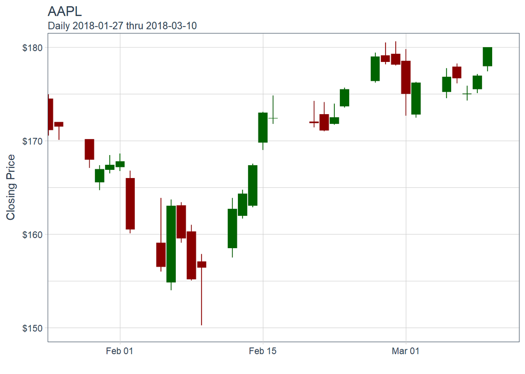

```r
start <- end - weeks(6)

AAPL %>%
  ggplot(aes(x = ,date, y = close)) +
  geom_candlestick(aes(open = open, high = high, low = low, close = close),
                   color_up = "darkgreen", color_down = "darkred",
                   fill_up  = "darkgreen", fill_down  = "darkred") +
  labs(title = "AAPL",
       subtitle = paste("Daily",start,"thru",end),
       y = "Closing Price", x = "") +
  coord_x_date(xlim = c(start, end),
               ylim = c(150, 180)) +
  theme_tq() +
  scale_y_continuous(labels = scales::dollar)
```

### Bollinger Bands

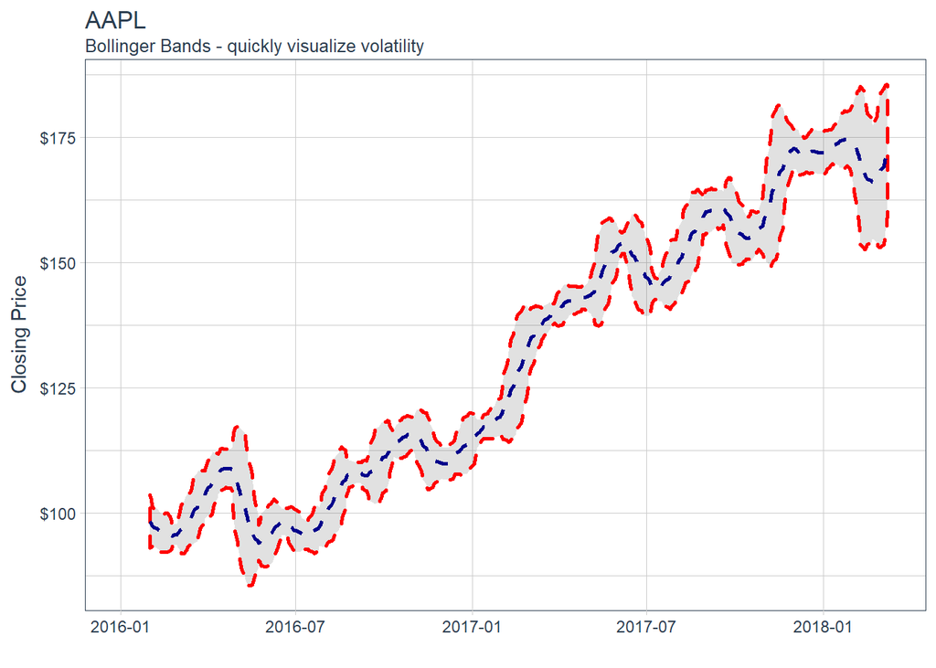

```r
AAPL %>%
  ggplot(aes(x = date, y = close)) +
  geom_bbands(aes(high = high, low = low, close = close),
              ma_fun = SMA, n = 20, sd = 2, size = 1) +
  labs(title = "AAPL",
       subtitle = "Bollinger Bands - quickly visualize volatility",
       x = "", y = "Closing Price") +
  theme_tq() +
  scale_y_continuous(labels = scales::dollar)
```

# Analysis Example: Multiple Stocks

### FANG (FB, AMZN, NFLX, GOOG)

### Load Daily Historical Data

```r
data(FANG)
```

### Compare Multiple Stocks

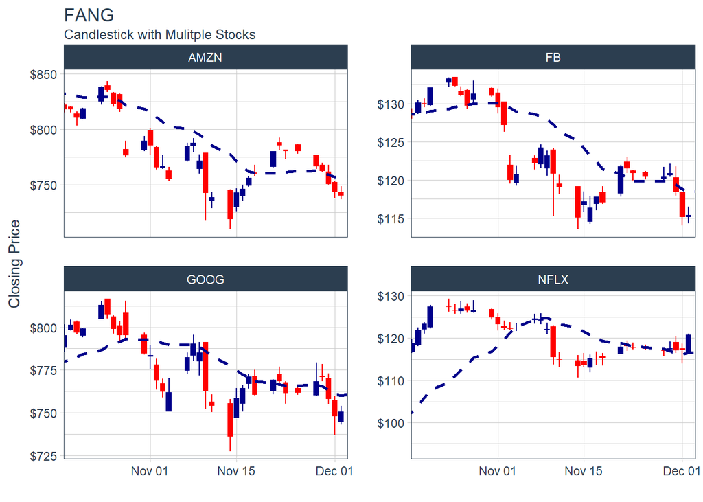

```r
end2 <- as_date("2016-12-01")

start2 <- end2 - weeks(6)

FANG %>%
  filter(date >= start2 - days(2 * 15)) %>%
  ggplot(aes(x = date, y = close, group = symbol)) +
  geom_candlestick(aes(open = open, high = high, low = low, close = close)) +
  geom_ma(ma_fun = SMA, n = 15, color = "darkblue", size = 1) +
  labs(title = "FANG",
       subtitle = "Candlestick with Mulitple Stocks",
       y = "Closing Price", x = "") +
  coord_x_date(xlim = c(start2, end2)) +
  facet_wrap(~ symbol, ncol = 2, scale = "free_y") +
  theme_tq() +
  scale_y_continuous(labels = scales::dollar)
```

# Interactive Candlestick Chart

#### Example: Using dygraphs<sup>[**6**](https://rstudio.github.io/dygraphs/)</sup> for R package

```r
# Get dygraphs
if (!require("dygraphs")) {

  install.packages("dygraphs")

  library(dygraphs)
}

data(sample_matrix)

m <- tail(sample_matrix, n = 32)

dygraph(m) %>% dyCandlestick() %>% dyRangeSelector()
```

[interactive chart not shown]

# References

**1** [tidyquant: Tidy Quantitative Financial Analysis (website)](https://cran.r-project.org/package=tidyquant)  
**2** [Introduction to tidyquant by Matt Dancho (website)](https://cran.r-project.org/web/packages/tidyquant/vignettes/TQ00-introduction-to-tidyquant.html)  
**3** [GitHub (source code)](https://github.com/business-science/tidyquant)  
**4** [tidyquant (website)](https://business-science.github.io/tidyquant/)  
**5** [FRED - Economic Research - Federal Reserve Bank of St. Louis (website)](https://fred.stlouisfed.org/categories)  
**6** [dygraphs for R (website)](https://rstudio.github.io/dygraphs/)